# Assignment 1

Tyler T.

Student Number: 100802975

Assignment Overview:

Decided area and data set: Tennis, ATP Tour 2022 data set.

ATP Tennis Rankings, Results, and Stats Link for dataset: https://github.com/JeffSackmann/tennis_atp My fork (in case Jeff’s one ever disappears): https://github.com/TylerTrott/tennis_atp

Which csv: atp_matches_2022.csv

What is included in this data set:

The ATP Tour 2022 data set covers the ATP 2022 Tour official tournaments. Each tournament has: - Tournament Name and ID - an, ‘n’, number of players (Draw Size) - Court Surface (Hard, Clay, Grass) - Tournament Winner - Length of Match

Every Tournament has players who play in the tournament. Every player has the following information: - Player Name - Player Rank - Player Age - Player Nationality (IOC - International Olympic Committee) - Player Shot Accuracy (Forehand - FH, Backhand - BH, Volley, and Serve) - Player match scores per tournament match - Number of rank points won/lost during tournament

Requirements

1. Incorporate aspects of data manipulation (e.g., dplyr, tidyr etc)
2. Written words - A discussion that talks about your chosen data set(s), and a discussion of the plots you did, questions they explore, and what they tell you.
3. Include at least 3 graphics: 2 basic including by not limited to: timeseries, bar, scatter, path etc, and 1 geographic map. You may have up to 5 graphics in your report.
4. Display a broad range of data visualisation skills to create attractive and professional looking plots (e.g, scales, themes, coordinate systems etc).
5. Your primary dataset should not be built into R (excluding maps).
6. Be communicated in the form of an R Notebook.

Questions I will be exploring with this dataset: - What are the probabilties of different age groups winning an ATP tour tournament match under specific time ranges? - What is the diversity within the ATP Tour for player nationality? - What nationalities appear more often in winning positions in comparison to losing ones? (who wins more, by country)

```r
# Setup workspace
graphics.off()
rm(list=ls())

# Yes, I'm actually using these.
require(ggplot2)
library(scales)
library(tidyverse)
library(rvest)
library(magrittr)
library(ggmap)
library(stringr)
library(countrycode)
library(geonames)
library("ggplot2")
theme_set(theme_bw())
library("sf")
library("rnaturalearth")
library("rnaturalearthdata")
library(cowplot)
library(googleway)
library(ggrepel)
library(ggspatial)
library(patchwork)
library("ggdensity")
library(ggforce)
library(ggdensity)
options(geonamesUsername="getafreeusernamefromgeonames.org")
```

Read the csv file - atp_matches_2022

```r
atpMatches <- read.csv('./atp_matches_2022.csv')
atpMatches
```

| tourney_id | tourney_name | surface | draw_size | tourney_level | tourney_date | match_num | winner_id | winner_seed | winner_entry | winner_name | winner_hand | winner_ht | winner_ioc | winner_age | loser_id | loser_seed | loser_entry | loser_name | loser_hand | loser_ht | loser_ioc | loser_age | score | best_of | round | minutes | w_ace | w_df | w_svpt | … |
| --- | --- | --- | --- | --- | --- | --- | --- | --- | --- | --- | --- | --- | --- | --- | --- | --- | --- | --- | --- | --- | --- | --- | --- | --- | --- | --- | --- | --- | --- | --- |
| 2022-8888 | Atp Cup | Hard | 16 | A | 20220103 | 300 | 200000 |  |  | Felix Auger Aliassime | R | 193 | CAN | 21.4 | 105138 |  |  | Roberto Bautista Agut | R | 183 | ESP | 33.7 | 7-6(3) 6-3 | 3 | F | 129 | 15 | 6 | 78 | … |
| 2022-8888 | Atp Cup | Hard | 16 | A | 20220103 | 299 | 133430 |  |  | Denis Shapovalov | L | 185 | CAN | 22.7 | 105807 |  |  | Pablo Carreno Busta | R | 188 | ESP | 30.4 | 6-4 6-3 | 3 | F | 98 | 7 | 2 | 78 | … |
| 2022-8888 | Atp Cup | Hard | 16 | A | 20220103 | 298 | 105138 |  |  | Roberto Bautista Agut | R | 183 | ESP | 33.7 | 128034 |  |  | Hubert Hurkacz | R | 196 | POL | 24.8 | 7-6(6) 2-6 7-6(5) | 3 | SF | 164 | 1 | 2 | 96 | … |
| 2022-8888 | Atp Cup | Hard | 16 | A | 20220103 | 297 | 105807 |  |  | Pablo Carreno Busta | R | 188 | ESP | 30.4 | 126591 |  |  | Jan Zielinski | R | NA | POL | 25.1 | 6-2 6-1 | 3 | SF | 53 | 6 | 0 | 45 | … |
| 2022-8888 | Atp Cup | Hard | 16 | A | 20220103 | 296 | 106421 |  |  | Daniil Medvedev | R | 198 | RUS | 25.8 | 200000 |  |  | Felix Auger Aliassime | R | 193 | CAN | 21.4 | 6-4 6-0 | 3 | SF | 68 | 6 | 4 | 41 | … |
| 2022-8888 | Atp Cup | Hard | 16 | A | 20220103 | 295 | 133430 |  |  | Denis Shapovalov | L | 185 | CAN | 22.7 | 126128 |  |  | Roman Safiullin | R | 185 | RUS | 24.4 | 6-4 5-7 6-4 | 3 | SF | 159 | 13 | 8 | 105 | … |
| 2022-8888 | Atp Cup | Hard | 16 | A | 20220103 | 294 | 134770 |  |  | Casper Ruud | R | 183 | NOR | 23.0 | 105583 |  |  | Dusan Lajovic | R | 180 | SRB | 31.5 | 6-3 7-5 | 3 | RR | 100 | 1 | 3 | 65 | … |
| 2022-8888 | Atp Cup | Hard | 16 | A | 20220103 | 293 | 105936 |  |  | Filip Krajinovic | R | 185 | SRB | 29.8 | 126340 |  |  | Viktor Durasovic | R | 185 | NOR | 24.7 | 6-2 7-5 | 3 | RR | 73 | 8 | 0 | 51 | … |
| 2022-8888 | Atp Cup | Hard | 16 | A | 20220103 | 292 | 106426 |  |  | Cristian Garin | R | 185 | CHI | 25.5 | 105583 |  |  | Dusan Lajovic | R | 180 | SRB | 31.5 | 4-6 6-4 3-0 RET | 3 | RR | 134 | 4 | 1 | 92 | … |
| 2022-8888 | Atp Cup | Hard | 16 | A | 20220103 | 291 | 105936 |  |  | Filip Krajinovic | R | 185 | SRB | 29.8 | 126214 |  |  | Alejandro Tabilo | L | 188 | CHI | 24.5 | 6-4 3-6 7-6(5) | 3 | RR | 145 | 5 | 2 | 97 | … |

[output cut: 2274 more lines]

Get countries and create a new DF that contains the number of occurences of that country. Both win and lose column

```r
allCountries <- select(atpMatches, winner_ioc, loser_ioc)
allCountries
```

| winner_ioc | loser_ioc |
| --- | --- |
| CAN | ESP |
| CAN | ESP |
| ESP | POL |
| ESP | POL |
| RUS | CAN |
| CAN | RUS |
| NOR | SRB |
| SRB | NOR |
| CHI | SRB |
| SRB | CHI |

[output cut: 2274 more lines]

Change country abbreviation to full name Have to make a column vector for winners/losers NOTE: Abbreviations are in IOC (International Olympic Committee)

```r
#### Winners ####
winningCountries <- countrycode(sourcevar = allCountries$winner_ioc, "ioc", "country.name")

# Get unique num of occurences for winning countries
occurencesWinning <- table(winningCountries)
# Create a DF that hosts unique set of countries, and number of times they occur
winningCountriesDF <- data.frame(unique(winningCountries), occurencesWinning)
#winningCountriesDF

#### Losers ####
losingCountries <-  countrycode(sourcevar = allCountries$loser_ioc, "ioc", "country.name")
occurencesLosing <- table(losingCountries)
# Create a DF that hosts unique set of countries, and number of times they occur
losingCountriesDF <- data.frame(unique(losingCountries), occurencesLosing)
```

Plot countries on world map for winners

```r
#### Setup world map for Winners ####
world <- ne_countries(scale = "medium", returnclass = "sf")
class(world)
```

```
## [1] "sf"         "data.frame"
```

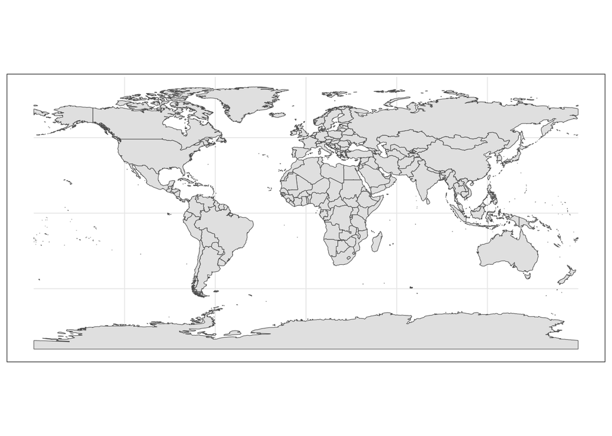

```r
ggplot(data = world) +
    geom_sf()
```

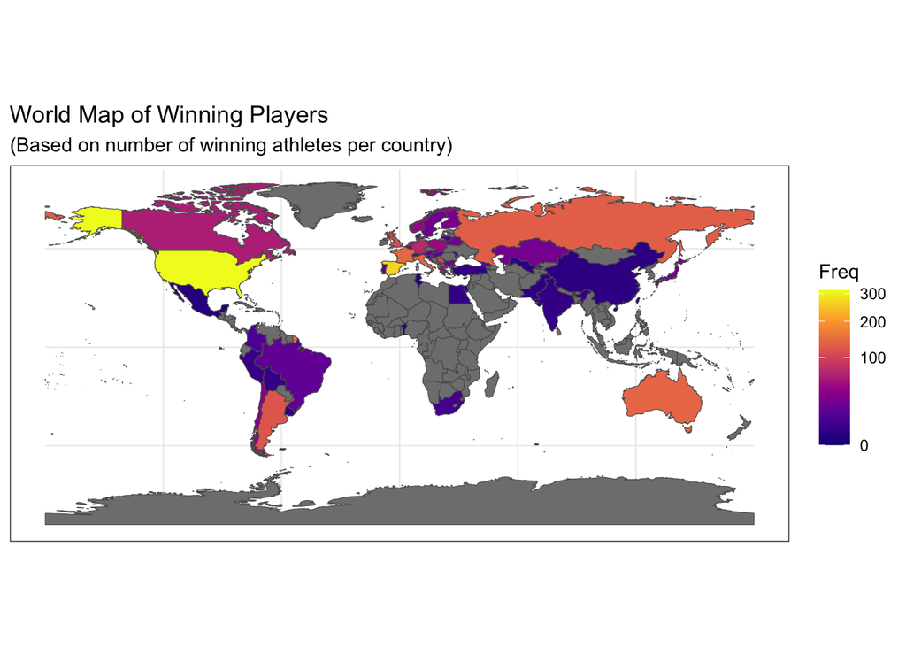

```r
# left join the winning countries df with world$NAME
world_freq <- left_join(world, winningCountriesDF, by = c("name" = "winningCountries"))

# replace any missing frequency values with zero
# list does not contain all countries of the world
if (any(is.na(world_freq$occurencesWinning))) {
  world_freq$occurencesWinning[is.na(world_freq$occurencesWinning)] <- 0
}

# Want to plot frequency of athletes from their respective countries
  ggplot(data = world_freq) +
    geom_sf(aes(fill = Freq)) +
    scale_fill_viridis_c(option = "plasma", trans = "sqrt", limits = c(0, max(world_freq$occurencesWinning))) +
    ggtitle("World Map of Winning Players",
    subtitle = paste0("(Based on number of winning athletes per country)"))
```

Plot countries on world map for losers

```r
#### Setup world map for Losers ####
world <- ne_countries(scale = "medium", returnclass = "sf")
class(world)
```

```
## [1] "sf"         "data.frame"
```

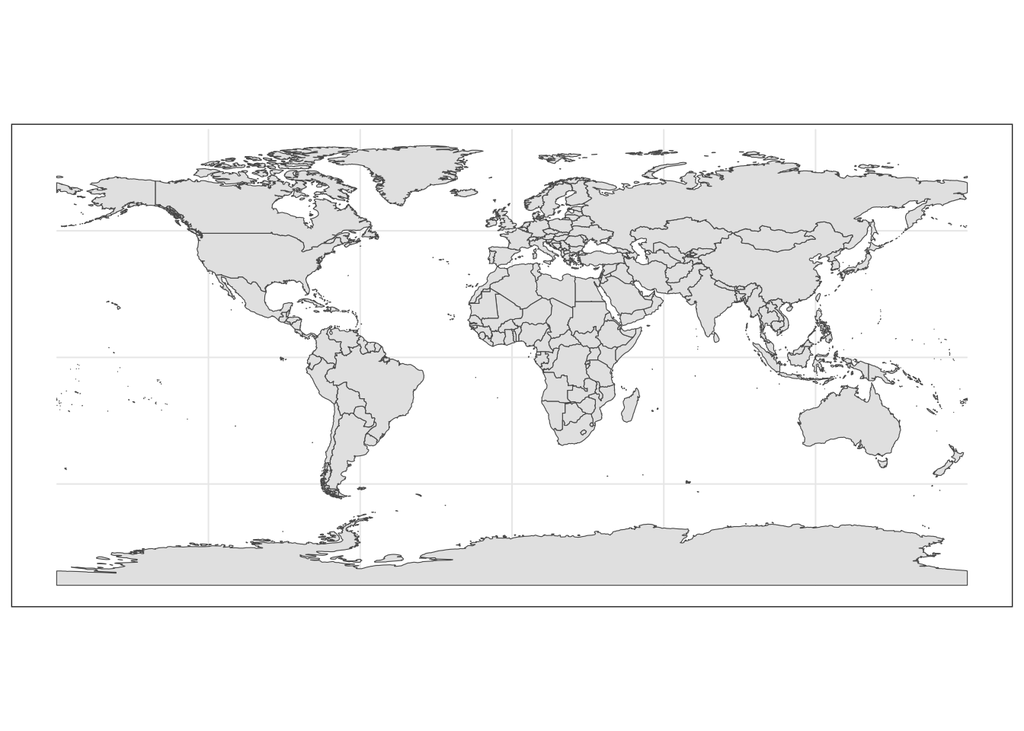

```r
ggplot(data = world) +
    geom_sf()
```

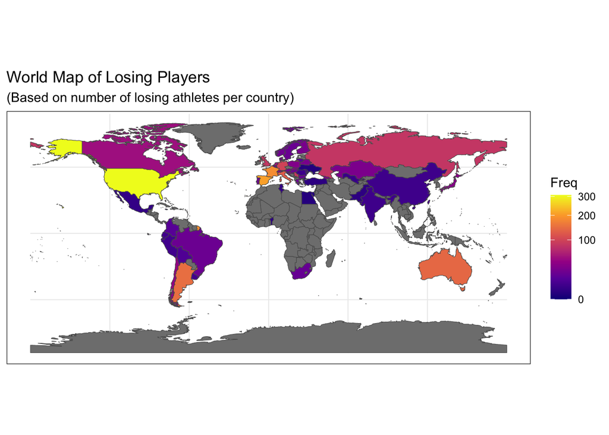

```r
# left join the winning countries df with world$NAME
world_freq <- left_join(world, losingCountriesDF, by = c("name" = "losingCountries"))

# replace any missing frequency values with zero
# list does not contain all countries of the world
if (any(is.na(world_freq$occurencesLosing))) {
  world_freq$occurencesLosing[is.na(world_freq$occurencesLosing)] <- 0
}

# Want to plot frequency of athletes from their respective countries
  ggplot(data = world_freq) +
    geom_sf(aes(fill = Freq)) +
    scale_fill_viridis_c(option = "plasma", trans = "sqrt", limits = c(0, max(world_freq$occurencesLosing))) +
    ggtitle("World Map of Losing Players",
    subtitle = paste0("(Based on number of losing athletes per country)"))
```

The following outputs both plots next to each other to see the differences. It is interesting to see that the US has the highest rate of winning and losing. From this, I am willing to assume that the US has a large amount of players who were active during the 2022 ATP season.

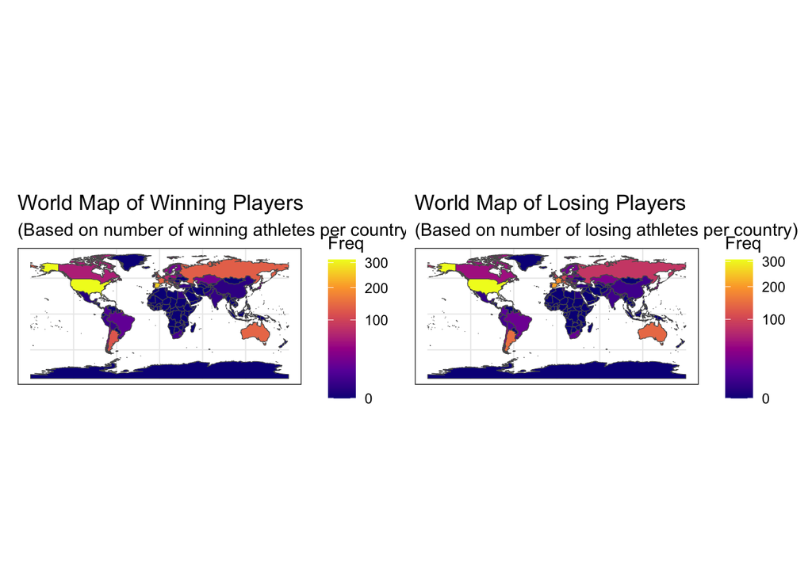

```r
# Winning plot
world_winning <- ne_countries(scale = "medium", returnclass = "sf")
world_freq_winning <- left_join(world_winning, winningCountriesDF, by = c("name" = "winningCountries"))
if (any(is.na(world_freq_winning$Freq))) {
  world_freq_winning$Freq[is.na(world_freq_winning$Freq)] <- 0
}
plot_winning <- ggplot(data = world_freq_winning) +
  geom_sf(aes(fill = Freq)) +
  scale_fill_viridis_c(option = "plasma", trans = "sqrt", limits = c(0, max(world_freq_winning$Freq))) +
  ggtitle("World Map of Winning Players", subtitle = paste0("(Based on number of winning athletes per country)"))

# Losing plot
world_losing <- ne_countries(scale = "medium", returnclass = "sf")
world_freq_losing <- left_join(world_losing, losingCountriesDF, by = c("name" = "losingCountries"))
if (any(is.na(world_freq_losing$Freq))) {
  world_freq_losing$Freq[is.na(world_freq_losing$Freq)] <- 0
}
plot_losing <- ggplot(data = world_freq_losing) +
  geom_sf(aes(fill = Freq)) +
  scale_fill_viridis_c(option = "plasma", trans = "sqrt", limits = c(0, max(world_freq_losing$Freq))) +
  ggtitle("World Map of Losing Players", subtitle = paste0("(Based on number of losing athletes per country)"))

# Combine plots using patchwork
plot_winning + plot_losing + plot_layout(ncol = 2)
```

I’m interested in seeing what the age differential is between the different court surfaces for the tournaments! With the knowledge that I have of tennis (I’ve been playing since I was 7 years old), before creating these diagrams, I suspect that the average age will be higher on Grass, followed by Clay, and then finally Hard. The surface matters for age due to the impact of the surface on a player’s joints! I am interested in seeing if this stays true, higher age with different surfaces, even for pro tournaments

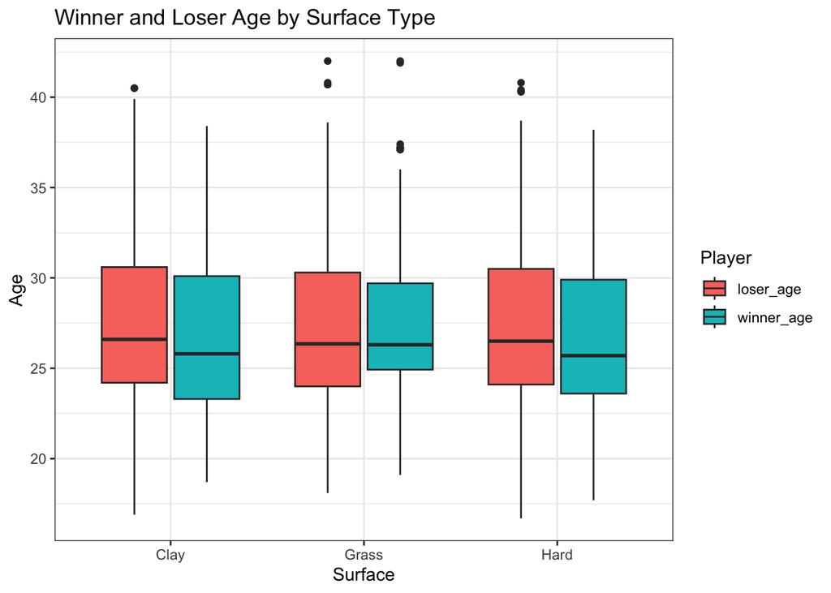

```r
# To see the difference in age and surface, we have to get those two
ageSurfaceDF <- select(atpMatches, winner_age, loser_age, surface)

df_long <- tidyr::pivot_longer(ageSurfaceDF, cols = c("winner_age", "loser_age"), names_to = "player", values_to = "age")
ggplot(df_long, aes(x = surface, y = age, fill = player)) +
  geom_boxplot() +
  labs(x = "Surface", y = "Age", fill = "Player") +
  ggtitle("Winner and Loser Age by Surface Type")
```

Upon close inspection, it actually looks like the ages are very close to each other! I wasn’t expecting to see a massive difference in the age groups, but it was shocking to me that the pool was close. What’s interesting are the outliers for grass. I think my earlier hypothesis was correct that there’d be more older players on that surface. This is still really cool. Having to be able to visualize information for something I love like tennis is so exciting!

I guess for my final part of this assignment, I’ll continue playing around with the age category. I’m interested in seeing what the age distribution looks like with winners against losers. To keep things spicy, I’m going to throw in the match duration category. How often do older players win in comparison to younger ones?

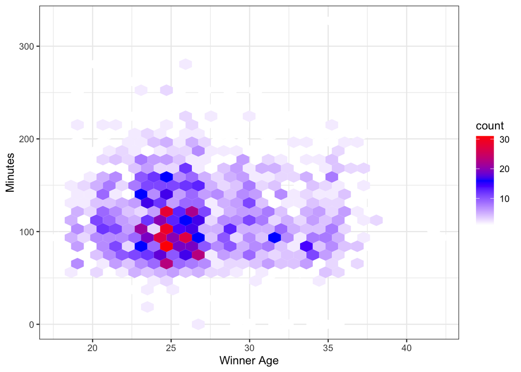

```r
# want to get ages and match duration 'minutes'
ageSurfaceDF <- select(atpMatches, winner_age, loser_age, surface, minutes)

# create scatter plot with density plot for winner age vs minutes
ggplot(ageSurfaceDF, aes(x = winner_age, y = minutes)) +
  geom_hex() +
  labs(x = "Winner Age", y = "Minutes") +
  scale_fill_gradientn(colors = c("white", "blue", "red"), na.value = "transparent") +
  theme_bw()
```

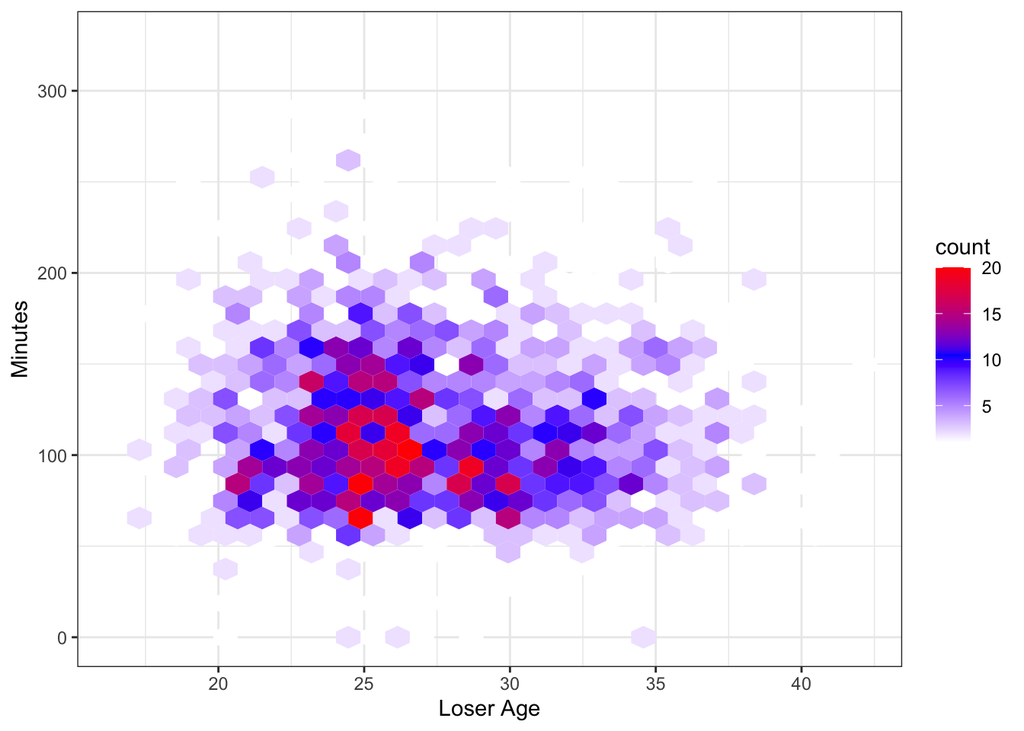

```r
# create scatter plot with density plot for loser age vs minutes
ggplot(ageSurfaceDF, aes(x = loser_age, y = minutes)) +
  geom_hex() +
  labs(x = "Loser Age", y = "Minutes") +
  scale_fill_gradientn(colors = c("white", "blue", "red"), na.value = "transparent") +
  theme_bw()
```

Looking at the above charts (I used HexBin! Isn’t it beautiful?), you can see that the winners are actually a bit younger than the losers. You can also see that players typically win/lose around the 100 minute mark. Very interesting! Most of these tournaments are best 2 out of 3 sets (sets are first to 6 games) and a set can take upwards of an hour.

What I can assume from this is that for those who are losing, they must be losing pretty badly haha. This was a lot of fun to work with!